# Retrieve KEGG Brite pathway information

Michael Jahn

16 Oktober, 2024

## KEGG (Brite) pathways

### Background

- Uniprot does not have good pathway annotation
- GO terms (obtained from Uniprot) are sometimes difficult to work with as they are too specific or unspecific
- GO terms have the (dis-) advantage of labelling a gene with many different functional classes
- what we often like to have instead is a simple overview about gene-pathway relationship
- simple means here that one gene is associated with only one or few descriptive functions
- KEGG (Brite) is a manually curated (not homology based) database that offers such information
- this example uses the Bioconductor package `KEGGRest` to retrieve pathways for the bacterium *Bacillus subtilis*.

### Libraries and test data

- Install `KEGGREST` package from Bioconductor

```r
BiocManager::install("KEGGREST")
```

- load required libraries

```r
suppressPackageStartupMessages({
  library(KEGGREST)
  library(tidyverse)
})
```

### Retrieve pathways

#### Starting with organism ID

- KEGG uses organism IDs, for *Bacillus subtilis* it is `bsu`
- using this ID, we can retrieve gene-pathway relationships using a premade R function
- internally it uses the `keggLink` function to find pathways and `keggList` to retrieve human readable pathway names
- it also trims some unnecessary text
- it can be used with organism ID (example: `bsu`) or gene ID (example: `bsu:BSU00040`)

```r
source("../source/get_kegg_pathways.R")
```

- apply function to retrieve pathways by organism

```r
df_kegg <- get_kegg_pathways(id = "bsu")
head(df_kegg)
```

| locus_tag | kegg_pathway_id | kegg_pathway |
| --- | --- | --- |
| BSU03050 | bsu00010 | Glycolysis / Gluconeogenesis |
| BSU03410 | bsu00010 | Glycolysis / Gluconeogenesis |
| BSU05840 | bsu00010 | Glycolysis / Gluconeogenesis |
| BSU08080 | bsu00010 | Glycolysis / Gluconeogenesis |
| BSU08090 | bsu00010 | Glycolysis / Gluconeogenesis |
| BSU09310 | bsu00010 | Glycolysis / Gluconeogenesis |

#### Starting with gene ID

- we can supply one or more IDs but they need to have the organism tag in the front

```r
df_kegg_genes <- get_kegg_pathways(id = c("bsu:BSU00040", "bsu:BSU20340"))
head(df_kegg_genes)
```

| locus_tag | kegg_pathway_id | kegg_pathway |
| --- | --- | --- |
| BSU00040 | bsu03440 | Homologous recombination |
| BSU20340 | bsu03030 | DNA replication |
| BSU20340 | bsu03430 | Mismatch repair |
| BSU20340 | bsu03440 | Homologous recombination |

### Results

- overview about most abundant pathways by locus_tag
- only top 10 pathways are shown

```r
df_summary <- df_kegg %>%
  group_by(kegg_pathway) %>%
  summarize(count = n()) %>%
  arrange(desc(count)) %>%
  slice(1:10)

head(df_summary)
```

| kegg_pathway | count |
| --- | --- |
| Metabolic pathways | 712 |
| Biosynthesis of secondary metabolites | 339 |
| Microbial metabolism in diverse environments | 183 |
| Biosynthesis of cofactors | 151 |
| Two-component system | 127 |
| ABC transporters | 126 |

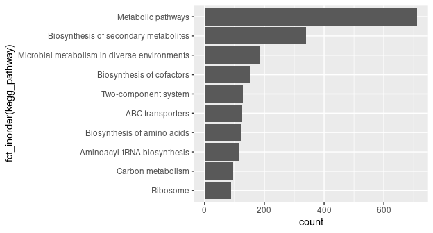

```r
df_summary %>%
  slice(10:1) %>%
  ggplot(aes(x = count, y = fct_inorder(kegg_pathway))) +
  geom_col()
```

```r
df_summary <- df_kegg %>%
  group_by(locus_tag) %>%
  summarize(genes_per_pathway = n()) %>%
  count(genes_per_pathway)

df_summary
```

| genes_per_pathway | n |
| --- | --- |
| 1 | 526 |
| 2 | 239 |
| 3 | 223 |
| 4 | 156 |
| 5 | 73 |
| 6 | 63 |
| 7 | 32 |
| 8 | 23 |
| 9 | 26 |
| 10 | 6 |

[output cut: 4 more lines]

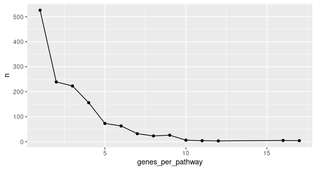

```r
df_summary %>%
  ggplot(aes(x = genes_per_pathway, y = n)) +
  geom_line() +
  geom_point()
```